# Försäkringskostnader

Malin

2026-04-01

# Försäkringsanalys

Syftet med denna analys är att undersöka vilka faktorer som påverkar försäkringskostnaderna mest. Datasetet innehåller information om kunder, livsstilsfaktorer och hälsorelaterade variabler, och analysen fokuserar på att identifiera mönster och samband i datan.

Rapporten inleds med en beskrivande analys för att få en överblick över datan, följt av en regressionsanalys för att undersöka vilka variabler som bäst förklarar kostnadsskillnaderna mellan kunder. Målet är att ge ett underlag för framtida prissättning.

## 1. Dataförståelse

```r
library(tidyverse)  # Datamanipulering och visualisering
library(skimr)      # Statistiska sammanfattningar
library(patchwork)  # Kombinerar flera grafer
library(broom)      # Snyggare tabeller från regressionsmodellerna

cost_raw <- read.csv("insurance_costs.csv")
```

```r
# Visar variabelnamn och datatyper som en formaterad tabell
tibble(
  variabel = names(cost_raw),
  datatyp = sapply(cost_raw, class)
)  %>%  knitr::kable()
```

| variabel | datatyp |
| --- | --- |
| customer_id | character |
| age | integer |
| sex | character |
| region | character |
| bmi | numeric |
| children | integer |
| smoker | character |
| chronic_condition | character |
| exercise_level | character |
| plan_type | character |
| prior_accidents | integer |
| prior_claims | integer |
| annual_checkups | numeric |
| charges | numeric |

```r
skim_without_charts(cost_raw)
```

Data summary

| Name | cost_raw |
| --- | --- |
| Number of rows | 1100 |
| Number of columns | 14 |
| _______________________ |  |
| Column type frequency: |  |
| character | 7 |
| numeric | 7 |
| ________________________ |  |
| Group variables | None |

**Variable type: character**

| skim_variable | n_missing | complete_rate | min | max | empty | n_unique | whitespace |
| --- | --- | --- | --- | --- | --- | --- | --- |
| customer_id | 0 | 1 | 7 | 7 | 0 | 1100 | 0 |
| sex | 0 | 1 | 4 | 6 | 0 | 2 | 0 |
| region | 0 | 1 | 4 | 6 | 0 | 6 | 0 |
| smoker | 0 | 1 | 2 | 3 | 0 | 4 | 0 |
| chronic_condition | 0 | 1 | 2 | 3 | 0 | 2 | 0 |
| exercise_level | 0 | 1 | 0 | 6 | 22 | 4 | 0 |
| plan_type | 0 | 1 | 5 | 8 | 0 | 6 | 0 |

**Variable type: numeric**

| skim_variable | n_missing | complete_rate | mean | sd | p0 | p25 | p50 | p75 | p100 |
| --- | --- | --- | --- | --- | --- | --- | --- | --- | --- |
| age | 0 | 1.00 | 42.51 | 12.37 | 18.00 | 34.00 | 42.50 | 51.00 | 75.00 |
| bmi | 28 | 0.97 | 27.43 | 4.59 | 17.00 | 24.30 | 27.50 | 30.60 | 44.00 |
| children | 0 | 1.00 | 1.57 | 1.47 | 0.00 | 0.00 | 1.00 | 3.00 | 5.00 |
| prior_accidents | 0 | 1.00 | 0.24 | 0.50 | 0.00 | 0.00 | 0.00 | 0.00 | 3.00 |
| prior_claims | 0 | 1.00 | 0.27 | 0.53 | 0.00 | 0.00 | 0.00 | 0.00 | 3.00 |
| annual_checkups | 20 | 0.98 | 2.09 | 1.16 | 0.00 | 1.00 | 2.00 | 3.00 | 4.00 |
| charges | 0 | 1.00 | 10060.49 | 4574.45 | 1203.51 | 6836.95 | 9124.31 | 12710.08 | 32559.28 |

```r
cost_raw %>% count(sex) %>% knitr::kable()
```

| sex | n |
| --- | --- |
| female | 551 |
| male | 549 |

```r
cost_raw %>% count(smoker) %>% knitr::kable()
```

| smoker | n |
| --- | --- |
| Yes | 4 |
| no | 892 |
| no | 4 |
| yes | 200 |

### Sammanfattning av dataförståelse

Datasetet består av 1100 kunder med 14 variabler som beskriver demografiska egenskaper, livsstilsfaktorer och försäkringskostnader. Medelåldern är 42.5 år och medelkostnaden uppgår till cirka 10 060 kr med en stor spridning, vilket indikerar att kostnaderna inte är normalfördelade.

Två variabler har saknade värden, bmi (28 observationer) och annual_checkups (20 observationer). Variabeln exercise_level har dessutom 22 tomma strängar som behöver konverteras till saknade värden.

Flera variabler lagras som text men är kategoriska till sin natur, exempelvis smoker, sex och region, och behöver konverteras till faktorer innan analysen. Inkonsekvent kapitalisering förekommer också och behöver hanteras.

Majoriteten av kunderna är icke-rökare och könsfördelningen är relativt jämn. Variablerna prior_accidents och prior_claims har medelvärden nära noll, vilket tyder på att skador och skadeanmälningar är ovanliga i kundstocken.

## 2. Datastädning och förberedelser

### Datastädning

```r
cost_clean <- cost_raw %>%
  mutate(
    # Tar bort mellanslag och gör om till gemena bokstäver
    sex = str_to_lower(str_trim(sex)),
    region = str_to_lower(str_trim(region)),
    smoker = str_to_lower(str_trim(smoker)),
    chronic_condition = str_to_lower(str_trim(chronic_condition)),
    exercise_level = str_to_lower(str_trim(exercise_level)),
    plan_type = str_to_lower(str_trim(plan_type)),
    # Konverterar tomma strängar till NA innan faktorkonvertering
    exercise_level = na_if(exercise_level, ""),
    # Gör om text till faktorer
    sex = as.factor(sex),
    region = as.factor(region),
    smoker = as.factor(smoker),
    chronic_condition = as.factor(chronic_condition),
    exercise_level = factor(exercise_level, levels = c("low", "medium", "high"), ordered = TRUE),
    plan_type = factor(plan_type, levels = c("basic", "standard", "premium"), ordered = TRUE),
    annual_checkups = as.integer(annual_checkups)
  ) %>%
  # Tar bort customer_id då den inte används i analysen
  select(-customer_id)
```

### BMI-kategorier

```r
cost_clean <- cost_clean %>%
  mutate(
    # BMI-kategorier enligt WHOs definitioner
    bmi_category = case_when(
      bmi < 18.5 ~ "undervikt",
      bmi < 25   ~ "normalvikt",
      bmi < 30   ~ "övervikt",
      bmi >= 30  ~ "fetma",
      TRUE       ~ NA_character_
    ),
    bmi_category = factor(bmi_category, levels = c("undervikt", "normalvikt", "övervikt", "fetma"), ordered = TRUE)
  )
```

### Kontroll av datatyper

```r
tibble(
  variabel = names(cost_clean),
  datatyp = sapply(cost_clean, class)
) %>% knitr::kable()
```

| variabel | datatyp |
| --- | --- |
| age | integer |
| sex | factor |
| region | factor |
| bmi | numeric |
| children | integer |
| smoker | factor |
| chronic_condition | factor |
| exercise_level | ordered, factor |
| plan_type | ordered, factor |
| prior_accidents | integer |
| prior_claims | integer |
| annual_checkups | integer |
| charges | numeric |
| bmi_category | ordered, factor |

```r
skim_without_charts(cost_clean)
```

Data summary

| Name | cost_clean |
| --- | --- |
| Number of rows | 1100 |
| Number of columns | 14 |
| _______________________ |  |
| Column type frequency: |  |
| factor | 7 |
| numeric | 7 |
| ________________________ |  |
| Group variables | None |

**Variable type: factor**

| skim_variable | n_missing | complete_rate | ordered | n_unique | top_counts |
| --- | --- | --- | --- | --- | --- |
| sex | 0 | 1.00 | FALSE | 2 | fem: 551, mal: 549 |
| region | 0 | 1.00 | FALSE | 4 | sou: 320, wes: 264, nor: 263, eas: 253 |
| smoker | 0 | 1.00 | FALSE | 2 | no: 896, yes: 204 |
| chronic_condition | 0 | 1.00 | FALSE | 2 | no: 832, yes: 268 |
| exercise_level | 22 | 0.98 | TRUE | 3 | med: 561, low: 307, hig: 210 |
| plan_type | 0 | 1.00 | TRUE | 3 | sta: 553, bas: 339, pre: 208 |
| bmi_category | 28 | 0.97 | TRUE | 4 | öve: 450, fet: 305, nor: 285, und: 32 |

**Variable type: numeric**

| skim_variable | n_missing | complete_rate | mean | sd | p0 | p25 | p50 | p75 | p100 |
| --- | --- | --- | --- | --- | --- | --- | --- | --- | --- |
| age | 0 | 1.00 | 42.51 | 12.37 | 18.00 | 34.00 | 42.50 | 51.00 | 75.00 |
| bmi | 28 | 0.97 | 27.43 | 4.59 | 17.00 | 24.30 | 27.50 | 30.60 | 44.00 |
| children | 0 | 1.00 | 1.57 | 1.47 | 0.00 | 0.00 | 1.00 | 3.00 | 5.00 |
| prior_accidents | 0 | 1.00 | 0.24 | 0.50 | 0.00 | 0.00 | 0.00 | 0.00 | 3.00 |
| prior_claims | 0 | 1.00 | 0.27 | 0.53 | 0.00 | 0.00 | 0.00 | 0.00 | 3.00 |
| annual_checkups | 20 | 0.98 | 2.09 | 1.16 | 0.00 | 1.00 | 2.00 | 3.00 | 4.00 |
| charges | 0 | 1.00 | 10060.49 | 4574.45 | 1203.51 | 6836.95 | 9124.31 | 12710.08 | 32559.28 |

### Sammanfattning av datastädning

I datastädningen har inkonsekvent kapitalisering och eventuella blanksteg hanterats. Textvariabler har gjorts om till faktorer för att underlätta användningen i regressionsanalysen. Variablerna exercise_level och plan_type har dessutom gjorts om till ordnade faktorer. annual_checkups har gjorts om från decimaltal till heltal. Variabeln customer_id har tagits bort då den inte kommer användas i analysen.

En ny variabel för BMI-kategorier har skapats baserad på WHOs definitioner för att göra det tydligare hur detta kopplar till hälsa. Ytterligare nya variabler som åldersgrupp och risknivå övervägdes men bedömdes inte tillföra något utöver de befintliga variablerna i analysen.

## 3. Beskrivande analys

### Tabeller över fördelning av kategoriska variabler

```r
cost_clean %>% count(sex) %>% knitr::kable()
```

| sex | n |
| --- | --- |
| female | 551 |
| male | 549 |

```r
cost_clean %>% count(smoker) %>% knitr::kable()
```

| smoker | n |
| --- | --- |
| no | 896 |
| yes | 204 |

```r
cost_clean %>% count(exercise_level) %>% knitr::kable()
```

| exercise_level | n |
| --- | --- |
| low | 307 |
| medium | 561 |
| high | 210 |
| NA | 22 |

```r
cost_clean %>% count(bmi_category) %>% knitr::kable()
```

| bmi_category | n |
| --- | --- |
| undervikt | 32 |
| normalvikt | 285 |
| övervikt | 450 |
| fetma | 305 |
| NA | 28 |

### Visualisering av fördelning av kategoriska variabler

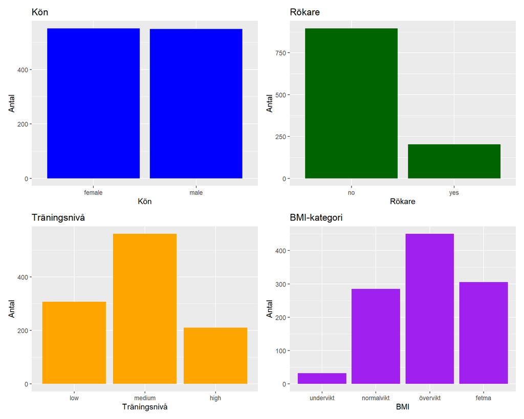

```r
p1 <- ggplot(cost_clean, aes(x = sex)) +
  geom_bar(fill = "blue") +
  labs(title = "Kön", x = "Kön", y = "Antal")

p2 <- ggplot(cost_clean, aes(x = smoker)) +
  geom_bar(fill = "darkgreen") +
  labs(title = "Rökare", x = "Rökare", y = "Antal")

p3 <- cost_clean %>%
  filter(!is.na(exercise_level)) %>%
  ggplot(aes(x = exercise_level)) +
  geom_bar(fill = "orange") +
  labs(title = "Träningsnivå", x = "Träningsnivå", y = "Antal")

p4 <- cost_clean %>%
  filter(!is.na(bmi_category)) %>%
  ggplot(aes(x = bmi_category)) +
  geom_bar(fill = "purple") +
  labs(title = "BMI-kategori", x = "BMI", y = "Antal")

(p1 + p2) / (p3 + p4)
```

#### Tolkning fördelning av kategoriska variabler

Könsfördelningen är jämn med 551 kvinnor och 549 män. Majoriteten av kunderna är icke-rökare (896 st) jämfört med rökare (204 st). Träningsnivån domineras av medium-nivå, medan high-nivå är minst vanlig. Flest kunder är överviktiga och det är något fler som har fetma än som är normalviktiga medan få är underviktiga.

### Fördelning av kostnader

```r
sammanfatta_kostnader <- function(data, grupp, caption ="") {
  data %>%
    filter(!is.na({{grupp}})) %>%
    group_by({{grupp}}) %>%
    summarise(
      medelvärde = mean(charges, na.rm = TRUE),
      median = median(charges, na.rm = TRUE),
      sd = sd(charges, na.rm = TRUE),
      antal = n(),
      .groups = "drop"
    ) %>%
    knitr::kable(digits = 0, caption = caption)
}

sammanfatta_kostnader(cost_clean, smoker, "Kostnader per rökarstatus")
```

Kostnader per rökarstatus

| smoker | medelvärde | median | sd | antal |
| --- | --- | --- | --- | --- |
| no | 8586 | 8232 | 3274 | 896 |
| yes | 16537 | 16392 | 3779 | 204 |

```r
sammanfatta_kostnader(cost_clean, exercise_level, "Kostnader per träningsnivå")
```

Kostnader per träningsnivå

| exercise_level | medelvärde | median | sd | antal |
| --- | --- | --- | --- | --- |
| low | 11576 | 10406 | 4920 | 307 |
| medium | 9753 | 8807 | 4393 | 561 |
| high | 8639 | 7723 | 3966 | 210 |

```r
sammanfatta_kostnader(cost_clean, bmi_category, "Kostnader per BMI-kategori")
```

Kostnader per BMI-kategori

| bmi_category | medelvärde | median | sd | antal |
| --- | --- | --- | --- | --- |
| undervikt | 8343 | 7145 | 4044 | 32 |
| normalvikt | 9218 | 8532 | 4397 | 285 |
| övervikt | 10119 | 9032 | 4391 | 450 |
| fetma | 10910 | 9845 | 4863 | 305 |

#### Tolkning av tabeller

Rökare har betydligt högre genomsnittliga kostnader än icke-rökare, vilket tyder på att rökning är en stark kostnadsdrivare. Träningsnivå visar ett svagare mönster, där låg träning har något högre kostnader än hög träning. BMI-kategorierna visar att fetma och övervikt är förknippade med högre kostnader jämfört med normalvikt.

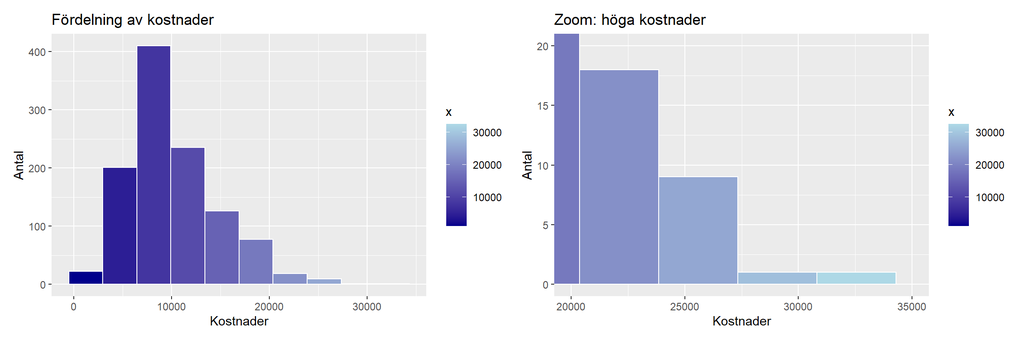

```r
pc1 <- ggplot(cost_clean, aes(x = charges, fill = after_stat(x))) +
  geom_histogram(bins = 10, color = "white") +
  scale_fill_gradient(low = "darkblue", high = "lightblue") +
  labs(title = "Fördelning av kostnader", x = "Kostnader", y = "Antal")

pc2 <- ggplot(cost_clean, aes(x = charges, fill = after_stat(x))) +
  geom_histogram(bins = 10, color = "white") +
  scale_fill_gradient(low = "darkblue", high = "lightblue") +
  # coord_cartesian zoomar in utan att ta bort data
  coord_cartesian(xlim = c(20000, 35000), ylim = c(0, 20)) +
  labs(title = "Zoom: höga kostnader", x = "Kostnader", y = "Antal")

pc1 + pc2
```

#### Tolkning av histogram

Kostnadsfördelningen är högersnedad med de flesta kunder i intervallet 5 000–15 000 kr. Zoom-grafen visar att ett fåtal kunder har mycket höga kostnader över 25 000 kr, vilket kan påverka modellens precision.

### Kostnader vs rökning och träningsnivå

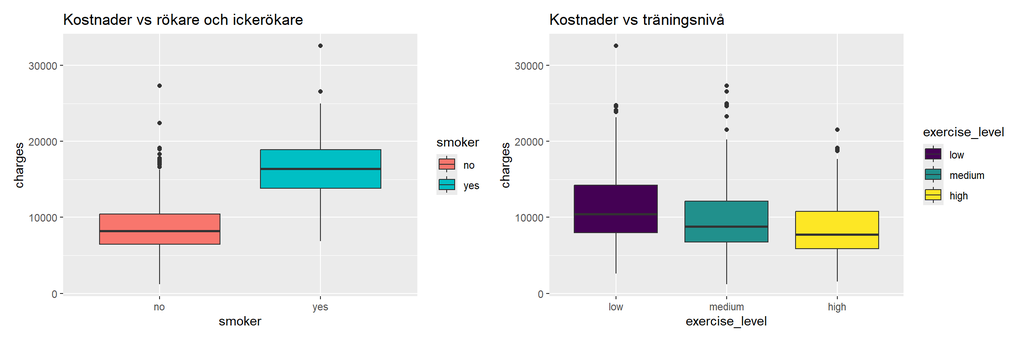

```r
psmo <- ggplot(cost_clean, aes(y = charges, x = smoker, fill = smoker)) +
  geom_boxplot() +
  labs(title = "Kostnader vs rökare och ickerökare")

pfit <- cost_clean %>%
  filter(!is.na(exercise_level)) %>%
  ggplot(aes(y = charges, x = exercise_level, fill = exercise_level)) +
  geom_boxplot() +
  labs(title = "Kostnader vs träningsnivå")

psmo + pfit
```

#### Tolkning kostnader vs rökning och träningsnivå

Rökare har tydligt högre kostnader med en median runt 16 000 kr jämfört med cirka 8 000 kr för icke-rökare. Träningsnivå visar ett svagare samband där skillnaderna mellan grupperna är mindre uttalade.

### Kostnader vs ålder och BMI

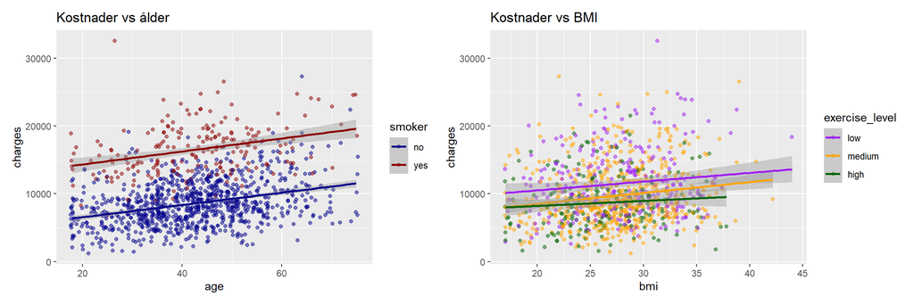

```r
page <- ggplot(cost_clean, aes(y = charges, x = age, color = smoker)) +
  # Jitter sprider punkter som ligger på varandra
  geom_point(alpha = 0.5, position = "jitter") +
  # geom_smooth lägger till en linjär trendlinje
  geom_smooth(method = "lm", se = TRUE) +
  scale_color_manual(values = c("no" = "darkblue", "yes" = "darkred")) +
  labs(title = "Kostnader vs ålder")

pbmi <- cost_clean %>%
  filter(!is.na(bmi), !is.na(exercise_level)) %>%
  ggplot(aes(y = charges, x = bmi, color = exercise_level)) +
  # Jitter sprider punkter som ligger på varandra
  geom_point(alpha = 0.5, position = "jitter") +
  # geom_smooth lägger till en linjär trendlinje
  geom_smooth(method = "lm", se = TRUE) +
  scale_color_manual(values = c("low" = "purple", "medium" = "orange", "high" = "darkgreen")) +
  labs(title = "Kostnader vs BMI")

page + pbmi
```

#### Tolkning kostnader vs ålder och BMI

Det finns ett positivt samband mellan ålder och kostnader, där äldre kunder tenderar att ha högre kostnader. Rökare (röda punkter) ligger genomgående högre än icke-rökare oavsett ålder. BMI-grafen visar inget lika tydligt mönster med träningsnivå.

### Skillnader mellan grupper

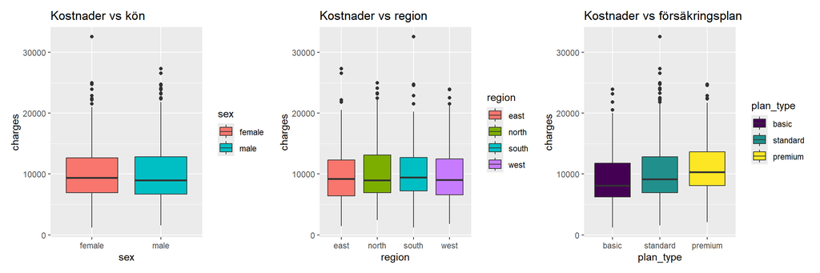

```r
psex <- ggplot(cost_clean, aes(y = charges, x = sex, fill = sex)) +
  geom_boxplot() +
  labs(title = "Kostnader vs kön")

preg <- ggplot(cost_clean, aes(y = charges, x = region, fill = region)) +
  geom_boxplot() +
  labs(title = "Kostnader vs region")

ppla <- ggplot(cost_clean, aes(y = charges, x = plan_type, fill = plan_type)) +
  geom_boxplot() +
  labs(title = "Kostnader vs försäkringsplan")

psex + preg + ppla
```

#### Tolkning skillnader mellan grupper

Köns- och regionsskillnaderna är små och troligen inte statistiskt betydelsefulla. Försäkringsplanen visar däremot ett tydligare mönster där premium-kunder har högre kostnader än basic-kunder, vilket kan bero på att premium-planer attraherar kunder med högre vårdbehov.

### Korrelation med försäkringskostnader

```r
cost_clean %>%
  summarise(
    cor_age = cor(charges, age, use = "complete.obs"),
    cor_bmi = cor(charges, bmi, use = "complete.obs"),
    cor_children = cor(charges, children, use = "complete.obs"),
    cor_prior_accidents = cor(charges, prior_accidents, use = "complete.obs"),
    cor_prior_claims = cor(charges, prior_claims, use = "complete.obs"),
    cor_annual_checkups = cor(charges, annual_checkups, use = "complete.obs")
  ) %>%
  knitr::kable(digits = 2, caption = "Korrelation med försäkringskostnader")
```

Korrelation med försäkringskostnader

| cor_age | cor_bmi | cor_children | cor_prior_accidents | cor_prior_claims | cor_annual_checkups |
| --- | --- | --- | --- | --- | --- |
| 0.26 | 0.15 | 0.03 | 0.24 | 0.18 | 0.06 |

#### Tolkning korrelation med försäkringskostnader

Korrelationsanalysen visar att ingen enskild numerisk variabel har ett starkt linjärt samband med försäkringskostnaderna. Ålder (0.26) och tidigare olyckor (0.24) har de starkaste sambanden, följt av tidigare skadeanmälningar (0.18) och BMI (0.15). Antal barn (0.03) och årliga hälsokontroller (0.06) visar mycket svaga samband med kostnaderna.

Det är värt att notera att rökning, som visade den tydligaste skillnaden i den beskrivande analysen, är en kategorisk variabel och ingår därför inte i korrelationstabellen. Det svaga linjära sambandet för de numeriska variablerna antyder att kostnaderna påverkas mer av kategoriska faktorer som rökning och försäkringsplan än av de numeriska variablerna.

## 4. Regressionsanalys

Urvalet av prediktorer baseras på den beskrivande analysen och korrelationstabellen. Rökning inkluderas då boxplotanalysen visade att rökare har nästan dubbelt så höga kostnader som icke-rökare, vilket är den tydligaste skillnaden i hela datasetet. Ålder och tidigare olyckor inkluderas eftersom de hade starkaste korrelationerna med försäkringskostnaderna (0.26 respektive 0.24). Tidigare skadeanmälningar (0.18) och BMI (0.15) inkluderas som hälso- och riskrelaterade variabler med lägre samband.

Kön och region utesluts då boxplotanalysen visade minimala skillnader mellan grupperna. Antal barn och årliga hälsokontroller utesluts på grund av mycket svaga korrelationer (0.03 respektive 0.06). Träningsnivå och försäkringsplan utesluts från grundmodellen men testas i en utökad modell för att undersöka om de förbättrar förklaringsgraden.

### Modelljämförelse

#### Modell 1

```r
model1 <- lm(charges ~ smoker + age + prior_accidents + prior_claims + bmi,
             data = cost_clean,
             # na.omit hanterar saknade värden lokalt i regressionen
             na.action = na.omit)

# glance och tidy från broom ger snyggare tabeller än summary
glance(model1) %>% knitr::kable(digits = 3, caption = "Modell 1 - modellstatistik")
```

Modell 1 - modellstatistik

| r.squared | adj.r.squared | sigma | statistic | p.value | df | logLik | AIC | BIC | deviance | df.residual | nobs |
| --- | --- | --- | --- | --- | --- | --- | --- | --- | --- | --- | --- |
| 0.586 | 0.585 | 2945.348 | 302.348 | 0 | 5 | -10081.21 | 20176.42 | 20211.26 | 9247628337 | 1066 | 1072 |

```r
tidy(model1) %>% knitr::kable(digits = 3, caption = "Modell 1")
```

Modell 1

| term | estimate | std.error | statistic | p.value |
| --- | --- | --- | --- | --- |
| (Intercept) | -6.526 | 619.939 | -0.011 | 0.992 |
| smokeryes | 7853.286 | 234.339 | 33.512 | 0.000 |
| age | 83.149 | 7.342 | 11.325 | 0.000 |
| prior_accidents | 869.406 | 187.190 | 4.645 | 0.000 |
| prior_claims | 1316.569 | 173.112 | 7.605 | 0.000 |
| bmi | 164.692 | 19.654 | 8.380 | 0.000 |

#### Modell 2 - utökad

```r
model2 <- lm(charges ~ smoker + age + prior_accidents + prior_claims + bmi + exercise_level + plan_type + chronic_condition,
             data = cost_clean,
             # na.omit hanterar saknade värden lokalt i regressionen
             na.action = na.omit)

# glance och tidy från broom ger snyggare tabeller än summary
glance(model2) %>% knitr::kable(digits = 3, caption = "Modell 2 - modellstatistik")
```

Modell 2 - modellstatistik

| r.squared | adj.r.squared | sigma | statistic | p.value | df | logLik | AIC | BIC | deviance | df.residual | nobs |
| --- | --- | --- | --- | --- | --- | --- | --- | --- | --- | --- | --- |
| 0.749 | 0.747 | 2305.575 | 310.789 | 0 | 10 | -9623.758 | 19271.52 | 19331.01 | 5528302366 | 1040 | 1051 |

```r
tidy(model2) %>% knitr::kable(digits = 3, caption = "Modell 2")
```

Modell 2

| term | estimate | std.error | statistic | p.value |
| --- | --- | --- | --- | --- |
| (Intercept) | 123.848 | 491.473 | 0.252 | 0.801 |
| smokeryes | 7466.690 | 186.658 | 40.002 | 0.000 |
| age | 67.590 | 5.842 | 11.569 | 0.000 |
| prior_accidents | 1014.134 | 148.690 | 6.820 | 0.000 |
| prior_claims | 902.261 | 138.915 | 6.495 | 0.000 |
| bmi | 159.575 | 15.594 | 10.233 | 0.000 |
| exercise_level.L | -1020.203 | 150.899 | -6.761 | 0.000 |
| exercise_level.Q | 191.141 | 117.902 | 1.621 | 0.105 |
| plan_type.L | 1116.591 | 149.012 | 7.493 | 0.000 |
| plan_type.Q | 112.491 | 118.224 | 0.952 | 0.342 |
| chronic_conditionyes | 3780.138 | 170.707 | 22.144 | 0.000 |

```r
tibble(
  modell = c("Modell 1", "Modell 2"),
  r_squared = c(
    summary(model1)$r.squared,
    summary(model2)$r.squared
  ),
  adjusted_r_squared = c(
    summary(model1)$adj.r.squared,
    summary(model2)$adj.r.squared
  ),
    residual_se = c(
    summary(model1)$sigma,
    summary(model2)$sigma
  )
) %>% knitr::kable(digits = 3, caption = "Modelljämförelse")
```

Modelljämförelse

| modell | r_squared | adjusted_r_squared | residual_se |
| --- | --- | --- | --- |
| Modell 1 | 0.586 | 0.585 | 2945.348 |
| Modell 2 | 0.749 | 0.747 | 2305.575 |

#### Tolkning modelljämförelse

De linjära komponenterna av träningsnivå, försäkringsplan och kronisk sjukdom är statistiskt signifikanta, vilket bekräftar att det var motiverat att inkludera dem i modell 2. De kvadratiska komponenterna av de ordnande variablerna (exercise_level.Q och plan_type.Q) är däremot inte signifikanta, vilket tyder på att sambanden är linjära snarare än böjda, vilket är förväntat för dessa variabler.

### Faktiska vs predikterade kostnader (modell 2)

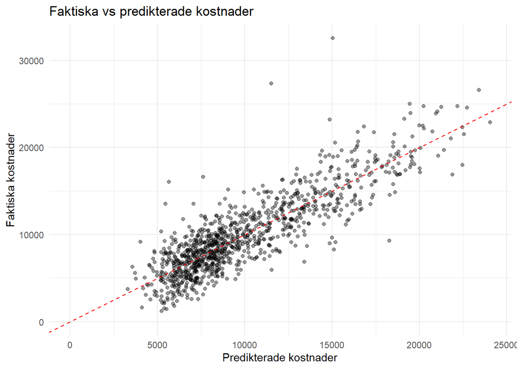

```r
cost_clean_pred <- cost_clean %>%
  filter(!is.na(bmi), !is.na(exercise_level)) %>%
  # Beräknar modellens predikterade värden för varje kund
  mutate(
    fitted_value = fitted(model2),
    residual = resid(model2)
  )

ggplot(cost_clean_pred, aes(x = fitted_value, y = charges)) +
  geom_point(alpha = 0.4) +
  geom_abline(slope = 1, intercept = 0, linetype = "dashed", color = "red") +
  expand_limits(x = 0, y = 0) +
  labs(title = "Faktiska vs predikterade kostnader",
       x = "Predikterade kostnader",
       y = "Faktiska kostnader") +
  theme_minimal()
```

#### Tolkning faktiska vs predikterade kostnader (modell 2)

Punkterna följer den röda linjen relativt väl, vilket indikerar att modellen har god anpassning. Den röda linjen representerar perfekt anpassning, dvs. där faktiska och predikterade kostnader är lika. Vid höga predikterade värden ökar spridningen något, vilket tyder på att modellen är något sämre på att förutsäga kostnader för de dyraste kunderna.

### Residualplot (modell 2)

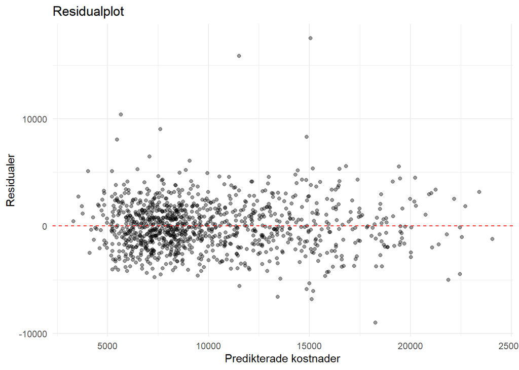

```r
ggplot(cost_clean_pred, aes(x = fitted_value, y = residual)) +
  geom_point(alpha = 0.4) +
  geom_hline(yintercept = 0, linetype = "dashed", color = "red") +
  labs(title = "Residualplot",
       x = "Predikterade kostnader",
       y = "Residualer") +
  theme_minimal()
```

### QQ-plot (modell 2)

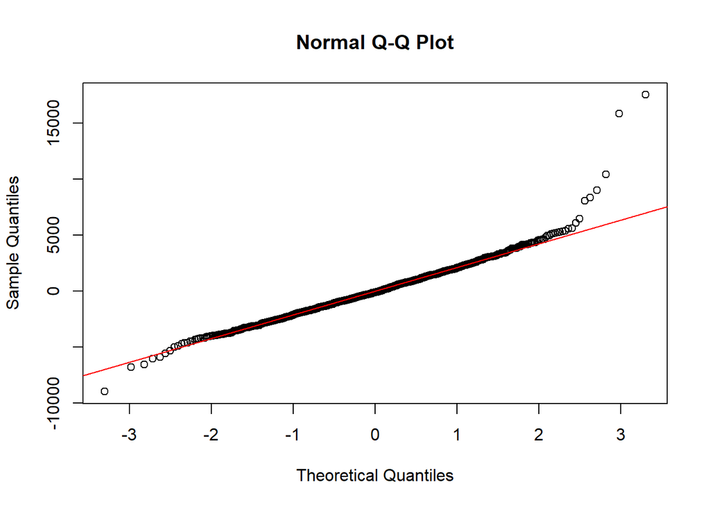

```r
qqnorm(resid(model2))
qqline(resid(model2), col = "red")
```

### Residualjämförelse modell 1 och modell 2

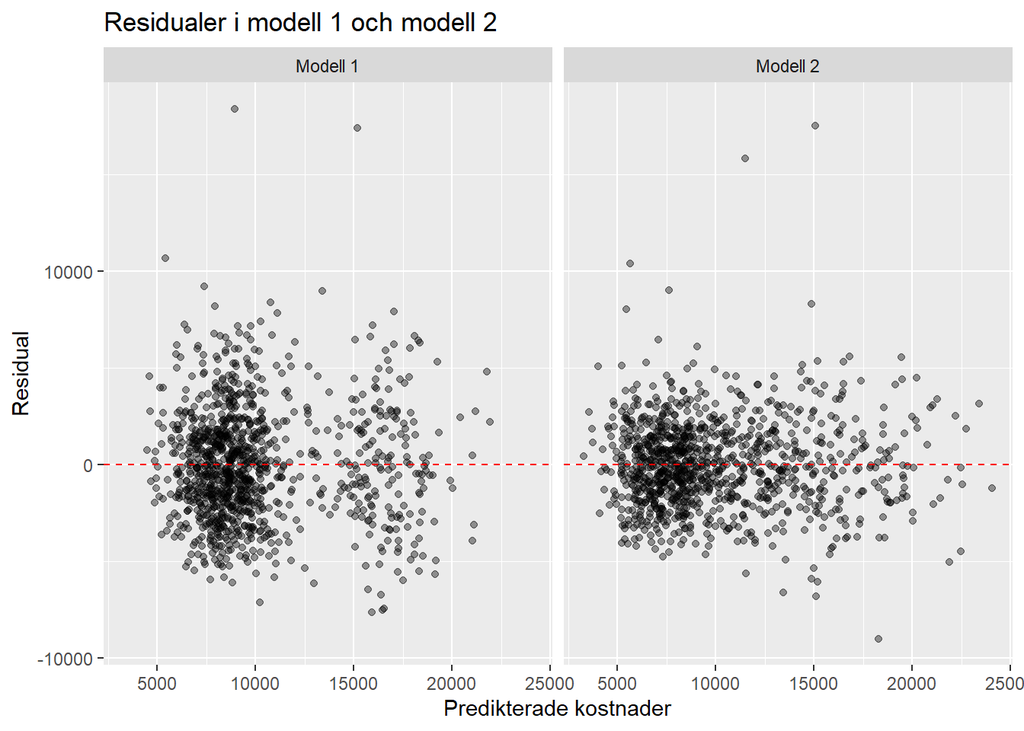

```r
model1_diagnostics <- cost_clean %>%
  filter(!is.na(bmi)) %>%
  mutate(
    fitted_value = fitted(model1),
    residual = resid(model1),
    model = "Modell 1"
  )

model2_diagnostics <- cost_clean %>%
  filter(!is.na(bmi), !is.na(exercise_level)) %>%
  mutate(
    fitted_value = fitted(model2),
    residual = resid(model2),
    model = "Modell 2"
  )

bind_rows(model1_diagnostics, model2_diagnostics) %>%
  ggplot(aes(x = fitted_value, y = residual)) +
  geom_point(alpha = 0.4) +
  geom_hline(yintercept = 0, linetype = "dashed", color = "red") +
  facet_wrap(~model) +
  labs(
    title = "Residualer i modell 1 och modell 2",
    x = "Predikterade kostnader",
    y = "Residual"
  )
```

#### Tolkning residualplot, QQ-plot och residualjämförelse modell 1 och modell 2

Residualerna är relativt jämnt fördelade runt nolllinjen, vilket tyder på att modellen inte systematiskt över- eller underskattar kostnaderna. Det finns dock några extrema outliers med mycket höga positiva residualer, vilket bekräftar att modellen underskattar kostnader för vissa kunder. Spridningen verkar också öka något vid högre predikterade värden, vilket är en av modellens begränsningar.

QQ-plotten visar att residualerna följer normalfördelningen väl i mitten, men avviker i svansarna – särskilt i den övre svansen där några extrema värden sticker ut. Detta bekräftar att modellen har svårare att förutsäga de dyraste kunderna.

Jämförelsen av residualer mellan modell 1 och modell 2 visar att modell 2 har något mindre spridning, vilket stämmer med det lägre residualstandardfelet i modelljämförelsetabellen.

Modell 1 visar ett mönster med två separata punktmoln, vilket troligen beror på att rökning skapar två distinkta kostnadsnivåer som modellen inte fullt ut fångar med enbart de fem prediktorerna. Detta mönster är mindre uttalat i modell 2, vilket tyder på att de tillkommande variablerna bidrar till en bättre anpassning.

### Sammanfattning av regressionsanalysen

Rökning är den starkaste prediktorn – rökare har i genomsnitt 7 467 kr högre kostnader än icke-rökare. Kronisk sjukdom är den näst starkaste faktorn med 3 780 kr högre kostnader. Högre träningsnivå är associerat med lägre kostnader (-1 020 kr) och högre försäkringsplan med högre kostnader. Ålder, BMI, tidigare olyckor och skadeanmälningar bidrar alla signifikant men med mindre effekter.

Det är värt att notera att koefficienten för tidigare skadeanmälningar sjunker från 1 317 i modell 1 till 902 i modell 2, vilket tyder på att en del av effekten i modell 1 egentligen förklaras av träningsnivå, försäkringsplan och kronisk sjukdom.

**Styrkor:**  
- Modellen förklarar 75% av variationen, vilket är starkt för verkliga data  
- Resultaten följer rimliga mönster – faktorer som rökning och kronisk sjukdom driver kostnader uppåt, vilket stämmer med vad man kan förvänta sig  
- Modellen kan användas som beslutsstöd vid framtida prissättning av liknande kunder

**Svagheter och begränsningar:**  
- 49 observationer togs bort på grund av saknade värden  
- Multikollinearitet mellan prediktorerna har inte undersökts  
- Modellen fångar endast linjära samband  
- Datasetet saknar variabler som rökarhistorik och socioekonomisk status

En möjlig förbättring av modellen vore att undersöka interaktionseffekter, t.ex. mellan BMI och träningsnivå, då trendlinjerna i figuren “Kostnader vs BMI” antyder att BMI påverkar kostnader olika beroende på träningsnivå.

## 5. Slutsatser

Analysen visar att rökning och kronisk sjukdom är de faktorer som tydligast driver försäkringskostnaderna, följt av ålder, BMI och tidigare olyckor och skadeanmälningar. Regressionsmodellen förklarar 75% av variationen i kostnaderna och bedöms kunna användas som beslutsstöd vid framtida prissättning.

Modellen fångar dock inte icke-linjära samband eller interaktionseffekter mellan variabler. Datasetet saknar också information som rökarhistorik och socioekonomisk status, vilket troligen påverkar kostnaderna i verkligheten.

Möjliga förbättringar inkluderar att undersöka interaktionseffekter, hantera de saknade värdena mer systematiskt samt komplettera datasetet med fler relevanta variabler.

## 6. Självreflektion

En styrka i arbetet är att datastädningen är noggrann och välmotiverad, och att valet av prediktorer baseras på både visualiseringar och korrelationsanalys. Regressionsanalysen innehåller två modeller med fullständig diagnostik och kritisk diskussion.

Det mest utmanande momentet var att tolka koefficienterna för de ordnade faktorerna och förstå hur förklaringskraften förändrades mellan modellerna där särskilt koefficienten för prior_claims skiljde sig mycket mellan modellerna.

Arbetet uppfyller enligt min bedömning kraven för VG, eftersom det inkluderar modeljämförelse, residualdiagnostik samt kritiskt resonemang kring modellens styrkor, begränsningar och möjliga förbättringar.